# Week 3: Milestone Report

Coursera Data Science Capstone

# Introduction

This report reviews the Explanatory Data Analaysis (EDA) I performed on the text data provided for the Coursera Data Science Specialization Capstone project. The data set includes 3 corpora of text, a set of Tweets, a set of blog posts, and a set of news articles. The goal of this analysis was to understand the scope of each corpora and recognize patterns in the text. I will also explain a brief plan for a prediction algorithm that attempts to finish a sentence based on input text.

# Basic Summary

The number of lines in each corpus is shown below:

| Source | Lines |
| --- | --- |
| Twitter | 2,360,148 |
| Blogs | 899,288 |
| News | 1,010,242 |

Due to the large size of each corpus I will only perform EDA on a sample of each dataset. The sample includes 5% of each corpus. The line count and word count of each corpus after sampling is below. We see that Twitter has the most lines but least words, which makes sense because we know tweets are short and character limited.

|  | Lines | Words | Distinct.Words |
| --- | --- | --- | --- |
| Twitter | 118,007 | 1,175,097 | 136,685 |
| Blog | 44,964 | 1,480,203 | 140,505 |
| News | 50,512 | 1,405,745 | 136,506 |

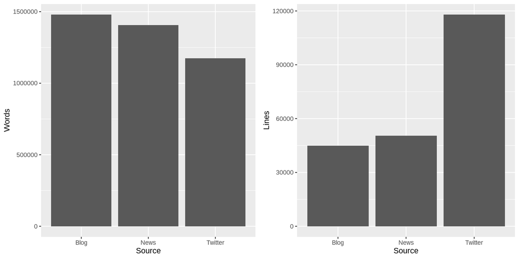

# Stop Words in the Corpus

|  | Words | Distinct.Words |
| --- | --- | --- |
| Twitter | 0.2997880 | 0.0374072 |
| Blog | 0.3519632 | 0.0274154 |
| News | 0.3010098 | 0.0163216 |

# Term Frequency

The following metrics are calculated with stop words removed. Additional text cleaning included removing punctuation, numbers, and stemming the document. I’ll look at the most frequent words and n-grams in each corpus.

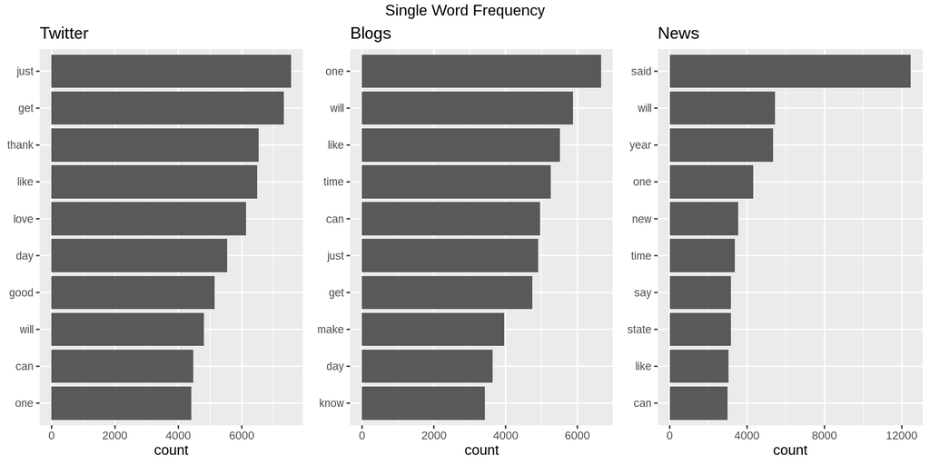

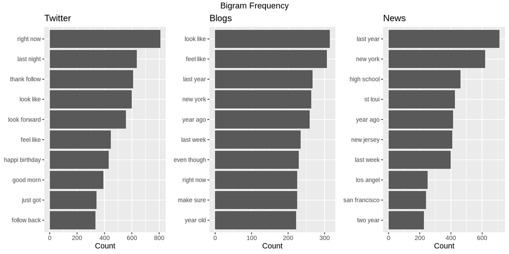

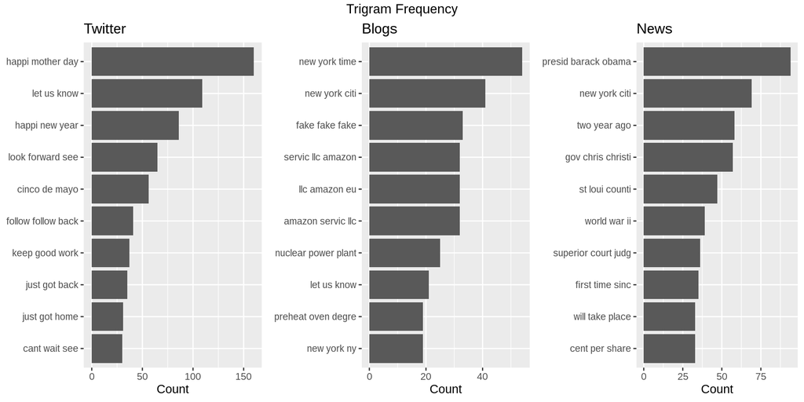

# Basic Prediction Model

A basic prediction model can be built off this data using the bigram and trigram frequency tables. By looking in the frequency tables for bigrams or trigrams that start with the input text, one can predict the most likely next word by knowing what n-gram appears most frequently. For example, if the input is “I like”, by searching for the most frequency trigram that begins with “I like” we can use the trigram to predict what the next word will be.